# 2024 NH3-loss Statistical Models, cube root

## Model A_Irrigation

Irrigation was modeled as a binomial variable due to heavy zero-inflation in the data.

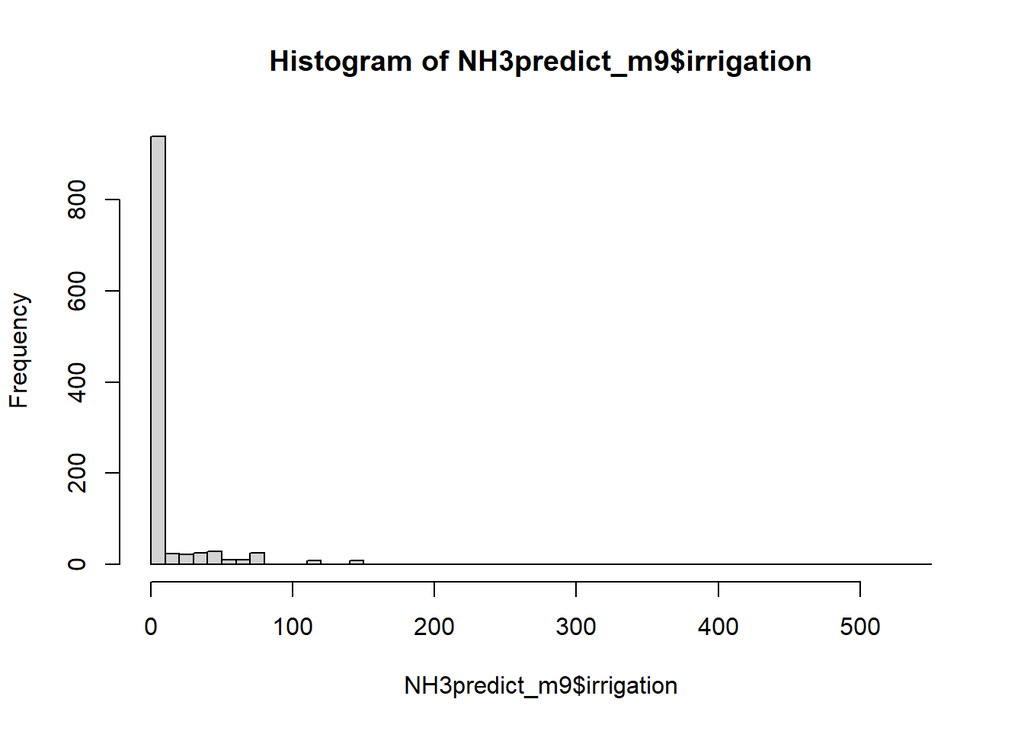

The number of observations in total in each category can be seen below:

```
##   irrigation_cat   N
## 1              0 900
## 2              1 202
```

```r
# Model
m9_lm <- lm(sign(NH3loss) * abs(NH3loss) ^ (1/3) ~ irrigation_cat + offset(M1_fit),
            weights=Weight,
            data=NH3predict_m9)
```

The check for normality and heteroscedasticity of errors can be seen below:

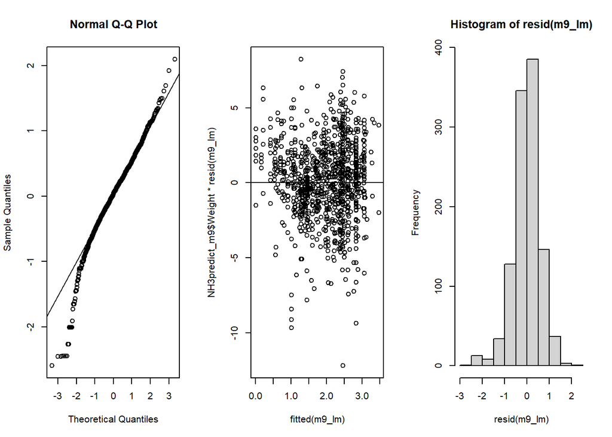

There was no effect of irrigation on NH3-loss (F(1, 1100) =0.31, p = 0.58).

```
##
## Call:
## lm(formula = sign(NH3loss) * abs(NH3loss)^(1/3) ~ irrigation_cat +
##     offset(M1_fit), data = NH3predict_m9, weights = Weight)
##
## Weighted Residuals:
##     Min      1Q  Median      3Q     Max
## -5.4694 -0.6934  0.0774  0.7943  4.1485
##
## Coefficients:
##                  Estimate Std. Error t value Pr(>|t|)
## (Intercept)      0.002339   0.019775   0.118    0.906
## irrigation_cat1 -0.024939   0.045002  -0.554    0.580
##
## Residual standard error: 1.254 on 1100 degrees of freedom
## Multiple R-squared:  0.0002791,  Adjusted R-squared:  -0.0006297
## F-statistic: 0.3071 on 1 and 1100 DF,  p-value: 0.5796
```

Adjusted R2-value of the model was -6.3^{-4}, and multiple R2 was 2.8^{-4}. The negative adjusted R2-value indicates that the amount of variation accounted for by irrigation is negligible. In practice, it explain no variation in the data.

The marginal means for NH3 loss in no-irrigation and irrigation categories can be seen below.

```
##   irrigation_cat   emmean         SE   df lower.CL upper.CL
## 1              0 1.909603 0.01977548 1100 1.870801 1.948405
## 2              1 1.884664 0.04042407 1100 1.805347 1.963981
```

[output not shown]

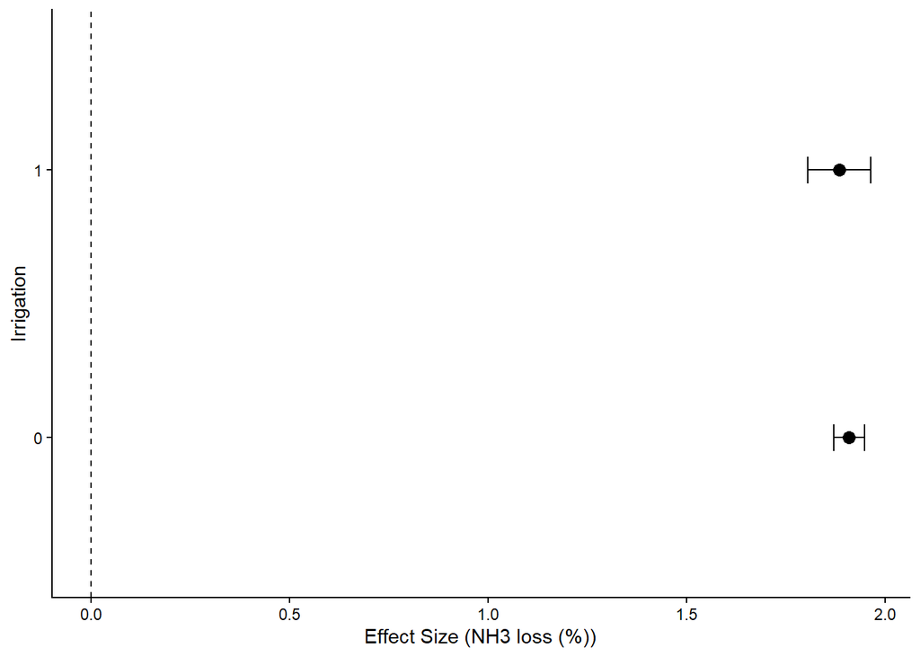

## Model A_Water input

Daily water input (mm) consists of irrigation and rainfall.

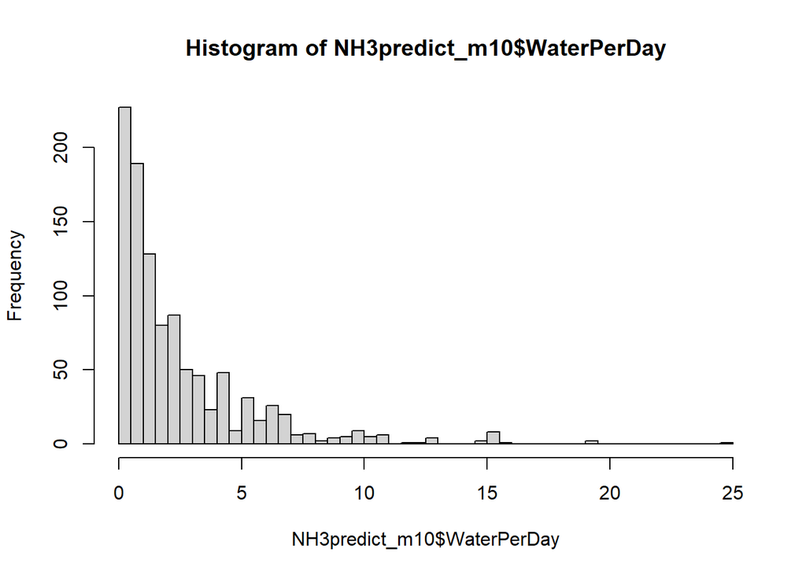

```r
#  Model
m10_lm <- lm(sign(NH3loss) * abs(NH3loss) ^ (1/3) ~ WaterPerDay + offset(M1_fit),
             weights=Weight,
             data=NH3predict_m10)
```

Heteroscedasticity and normality of erros were as below:

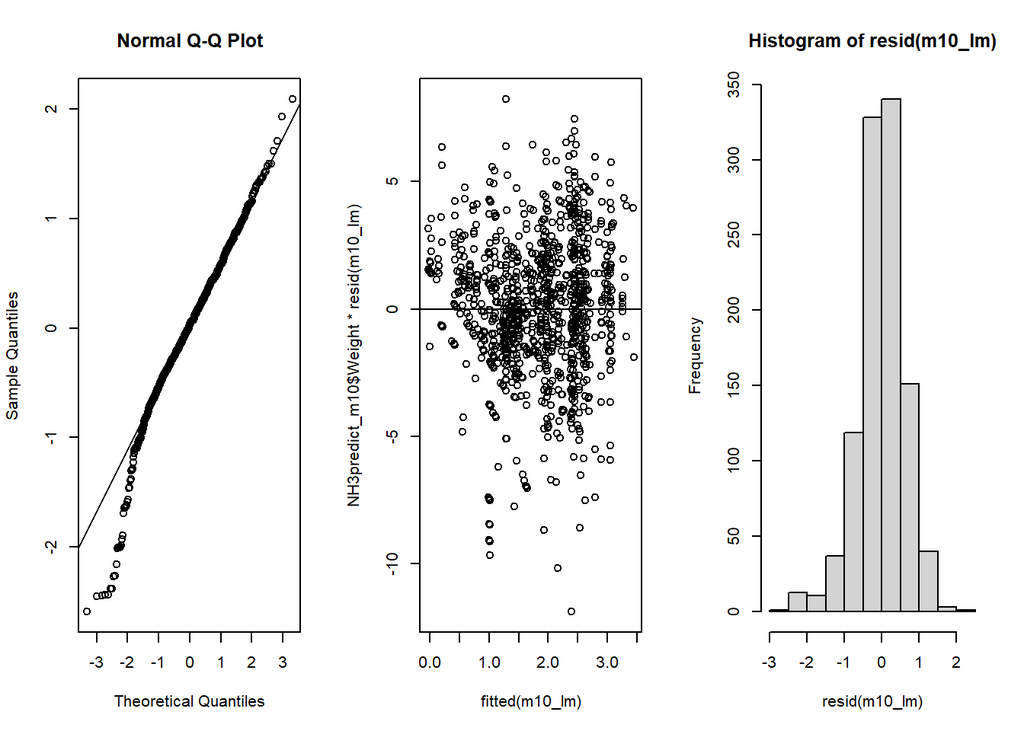

There was no effect of water input on NH3-loss (F(1, 1042) =2.56, p = 0.11).

```
##
## Call:
## lm(formula = sign(NH3loss) * abs(NH3loss)^(1/3) ~ WaterPerDay +
##     offset(M1_fit), data = NH3predict_m10, weights = Weight)
##
## Weighted Residuals:
##     Min      1Q  Median      3Q     Max
## -5.3259 -0.7431  0.0663  0.8332  4.1458
##
## Coefficients:
##              Estimate Std. Error t value Pr(>|t|)
## (Intercept)  0.018231   0.025194   0.724    0.469
## WaterPerDay -0.010700   0.006691  -1.599    0.110
##
## Residual standard error: 1.315 on 1042 degrees of freedom
## Multiple R-squared:  0.002448,   Adjusted R-squared:  0.001491
## F-statistic: 2.557 on 1 and 1042 DF,  p-value: 0.1101
```

```
## Analysis of Variance Table
##
## Response: sign(NH3loss) * abs(NH3loss)^(1/3)
##               Df  Sum Sq Mean Sq F value Pr(>F)
## WaterPerDay    1    4.42  4.4242  2.5571 0.1101
## Residuals   1042 1802.82  1.7302
```

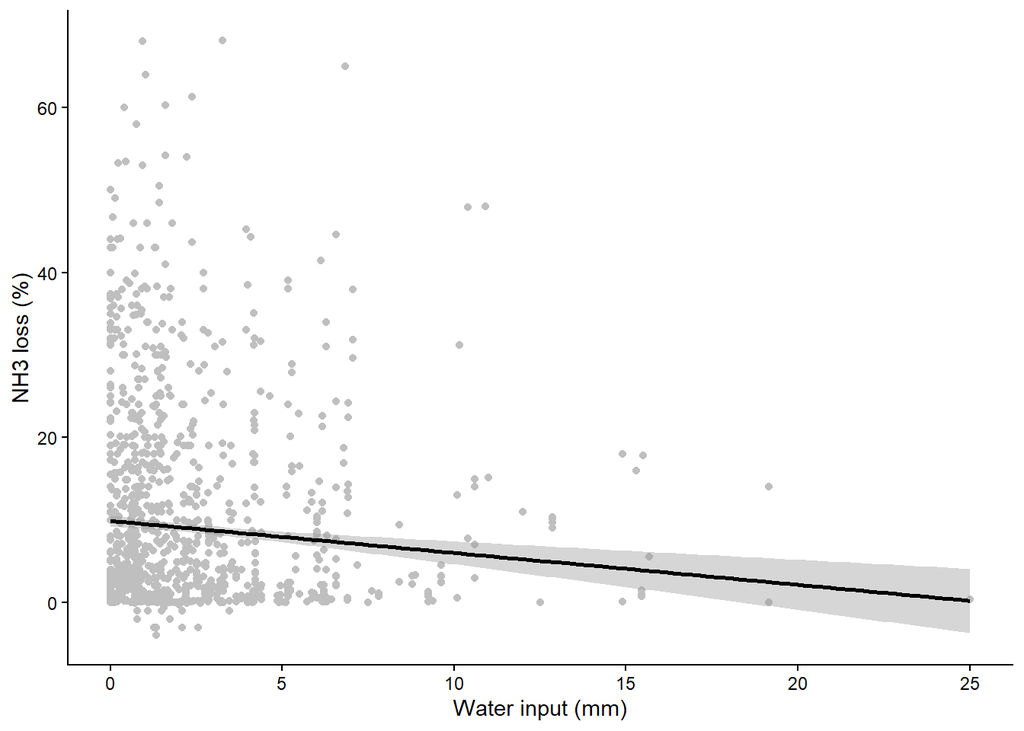

## Model A_Experiment duration

Duration of the experiment (days).

```
##    Min. 1st Qu.  Median    Mean 3rd Qu.    Max.
##    3.00    9.00   15.00   18.49   25.00  120.00
```

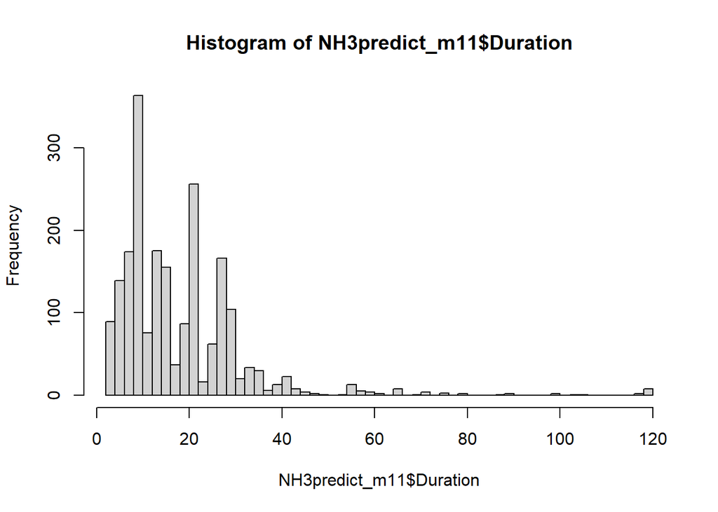

```r
#  Model
m11_lm <- lm(sign(NH3loss) * abs(NH3loss) ^ (1/3) ~ Duration + offset(M1_fit),
             weights=Weight,
             data=NH3predict_m11)
```

Heteroscedasticity and normality of erros were as below:

[figure not shown]

There was no effect of duration of the experiment on NH3-loss (F(1, 2098) =0.16, p = 0.691).

```
##
## Call:
## lm(formula = sign(NH3loss) * abs(NH3loss)^(1/3) ~ Duration +
##     offset(M1_fit), data = NH3predict_m11, weights = Weight)
##
## Weighted Residuals:
##     Min      1Q  Median      3Q     Max
## -5.4526 -0.7771  0.0328  0.8119  4.6875
##
## Coefficients:
##               Estimate Std. Error t value Pr(>|t|)
## (Intercept) -0.0081512  0.0216117  -0.377    0.706
## Duration     0.0003701  0.0009299   0.398    0.691
##
## Residual standard error: 1.305 on 2098 degrees of freedom
## Multiple R-squared:  7.549e-05,  Adjusted R-squared:  -0.0004011
## F-statistic: 0.1584 on 1 and 2098 DF,  p-value: 0.6907
```

```
## Analysis of Variance Table
##
## Response: sign(NH3loss) * abs(NH3loss)^(1/3)
##             Df Sum Sq Mean Sq F value Pr(>F)
## Duration     1    0.3 0.26973  0.1584 0.6907
## Residuals 2098 3572.6 1.70284
```

Adjusted R2-value of the model was -4^{-4}, and multiple R2 was 8^{-5}. The negative adjusted R2-value indicates that the amount of variation accounted for by duration of the experiment is negligible. In practice, it explain no variation in the data.

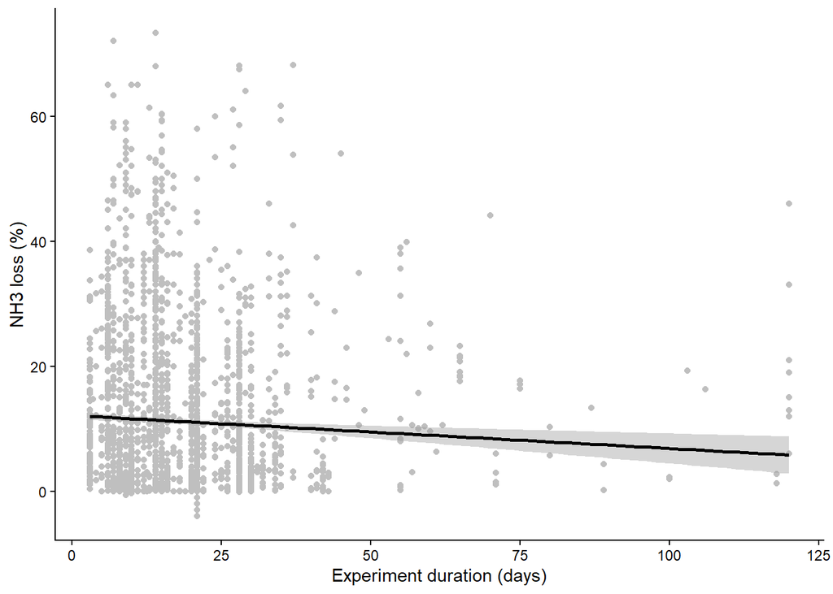

## Combined model with all variables of effect

### Model A1_Base model and pH

```
## Type III Analysis of Variance Table with Satterthwaite's method
##                    Sum Sq Mean Sq NumDF   DenDF  F value    Pr(>F)
## Fertiliser        1473.13  491.04     3 2408.25 275.3800 < 2.2e-16 ***
## Application        276.86   92.29     3 2152.68  51.7543 < 2.2e-16 ***
## Method              52.49    8.75     6  352.49   4.9057 7.802e-05 ***
## Place               63.90   63.90     1  470.83  35.8344 4.263e-09 ***
## pH_cat             161.60  161.60     1 2479.96  90.6272 < 2.2e-16 ***
## Fertiliser:pH_cat  183.29   61.10     3 2391.85  34.2642 < 2.2e-16 ***
## ---
## Signif. codes:  0 '***' 0.001 '**' 0.01 '*' 0.05 '.' 0.1 ' ' 1
```

```
## Linear mixed model fit by REML. t-tests use Satterthwaite's method [
## lmerModLmerTest]
## Formula: sign(NH3loss) * abs(NH3loss)^(1/3) ~ Fertiliser + Application +
##     Method + Place + pH_cat + Fertiliser:pH_cat + (1 | Ref)
##    Data: NH3predict_mALL5
## Weights: Weight
## Control: lmerControl(optimizer = "bobyqa")
##
## REML criterion at convergence: 5205.4
##
## Scaled residuals:
##     Min      1Q  Median      3Q     Max
## -5.7774 -0.5153  0.0214  0.6024  3.4687
##
## Random effects:
##  Groups   Name        Variance Std.Dev.
##  Ref      (Intercept) 0.3415   0.5844
##  Residual             1.7831   1.3353
## Number of obs: 2500, groups:  Ref, 246
##
## Fixed effects:
##                                     Estimate Std. Error         df t value
## (Intercept)                          2.61881    0.10669  559.99618  24.546
## FertiliserUAN                       -0.43363    0.11712 2474.29031  -3.702
## Fertiliserammonium+1                -1.01249    0.06699 2447.83748 -15.115
## Fertiliserammonium+2                -1.62414    0.05446 2346.30067 -29.823
## ApplicationIncorporated             -0.73445    0.06111 2318.18111 -12.018
## ApplicationInjected                 -0.71192    0.21227 2476.12686  -3.354
## ApplicationLiquid                   -0.25605    0.07794 1777.36138  -3.285
## Method15N                           -0.54530    0.35793 2319.12230  -1.523
## MethodClosed chamber                -0.53046    0.13214  461.04243  -4.014
## MethodDrager-Tube                   -0.68018    0.23295  208.57507  -2.920
## MethodSemi-open                     -0.06829    0.16950  296.56177  -0.403
## MethodVentilated chambers           -0.34451    0.12400  757.38322  -2.778
## MethodWindtunnel                     0.10380    0.16415  408.42644   0.632
## PlaceLab                             0.53437    0.08927  470.82677   5.986
## pH_catchalky                         0.06242    0.04373 2462.62056   1.428
## FertiliserUAN:pH_catchalky           0.40890    0.15331 2460.05304   2.667
## Fertiliserammonium+1:pH_catchalky    0.73802    0.08544 2392.66426   8.637
## Fertiliserammonium+2:pH_catchalky    0.59789    0.08546 2341.38695   6.996
##                                   Pr(>|t|)
## (Intercept)                        < 2e-16 ***
## FertiliserUAN                     0.000218 ***
## Fertiliserammonium+1               < 2e-16 ***
## Fertiliserammonium+2               < 2e-16 ***
## ApplicationIncorporated            < 2e-16 ***
## ApplicationInjected               0.000809 ***
## ApplicationLiquid                 0.001038 **
## Method15N                         0.127772
## MethodClosed chamber              6.96e-05 ***
## MethodDrager-Tube                 0.003888 **
## MethodSemi-open                   0.687309
## MethodVentilated chambers         0.005599 **
## MethodWindtunnel                  0.527496
## PlaceLab                          4.26e-09 ***
## pH_catchalky                      0.153561
## FertiliserUAN:pH_catchalky        0.007700 **
## Fertiliserammonium+1:pH_catchalky  < 2e-16 ***
## Fertiliserammonium+2:pH_catchalky 3.42e-12 ***
## ---
## Signif. codes:  0 '***' 0.001 '**' 0.01 '*' 0.05 '.' 0.1 ' ' 1
```

```
##
## Correlation matrix not shown by default, as p = 18 > 12.
## Use print(x, correlation=TRUE)  or
##     vcov(x)        if you need it
```

Total observations = 2500

Model A1 explains 28.92 % of the variation in the data (conditional R2), with the fixed effects explaining 15.3 % (marginal R2). The R2-values for linear mixed effects model were calculated according to Nagakawa & Schielzeth (2013).

```
##                Factor               Level     Effect         SE         df
## 1          Fertiliser               urea+ 17.9602194 0.10692874  1782.7255
## 2          Fertiliser                 UAN 10.4341938 0.15619170  4741.3052
## 3          Fertiliser          ammonium+1  4.1447628 0.12309421  2761.6805
## 4          Fertiliser          ammonium+2  0.9840971 0.11772777  2444.1873
## 5         Application           Broadcast 17.9602194 0.10692874  1782.7255
## 6         Application        Incorporated  6.6910240 0.12067781  2499.8980
## 7         Application            Injected  6.9339063 0.23791261 16809.8568
## 8         Application              Liquid 13.1904474 0.12722243  2287.9661
## 9              Method            Micromet 17.9602194 0.10692874  1782.7255
## 10             Method                 15N  8.9149556 0.34420524 24642.4336
## 11             Method      Closed chamber  9.1077261 0.09053636   621.0526
## 12             Method         Drager-Tube  7.2859660 0.21081219   232.3136
## 13             Method           Semi-open 16.5914947 0.13333490   733.0609
## 14             Method Ventilated chambers 11.7637054 0.08674965   993.1276
```

[output cut: 41 more lines]

### Model A2_Base model, pH, and Clay

A knowledge of air temperature means having access to data concerning the date, time and location of fertilizer applications. If these data are not available, a model that omits this variable but includes the clay content of the soil could be advantageous, since the clay content will often be known.

```
## Type III Analysis of Variance Table with Satterthwaite's method
##                    Sum Sq Mean Sq NumDF  DenDF  F value    Pr(>F)
## Fertiliser        1442.12  480.71     3 2208.4 280.4079 < 2.2e-16 ***
## Application        198.22   66.07     3 2024.5  38.5414 < 2.2e-16 ***
## Method              58.37    9.73     6  335.9   5.6749 1.239e-05 ***
## Place               62.94   62.94     1  455.6  36.7118 2.871e-09 ***
## pH_cat             174.05  174.05     1 2272.4 101.5251 < 2.2e-16 ***
## Clay                51.16   51.16     1 2176.3  29.8431 5.219e-08 ***
## Fertiliser:pH_cat  161.24   53.75     3 2194.9  31.3511 < 2.2e-16 ***
## ---
## Signif. codes:  0 '***' 0.001 '**' 0.01 '*' 0.05 '.' 0.1 ' ' 1
```

```
## Linear mixed model fit by REML. t-tests use Satterthwaite's method [
## lmerModLmerTest]
## Formula: sign(NH3loss) * abs(NH3loss)^(1/3) ~ Fertiliser + Application +
##     Method + Place + pH_cat + Fertiliser:pH_cat + Clay + (1 |      Ref)
##    Data: NH3predict_mALL2
## Weights: Weight
## Control: lmerControl(optimizer = "bobyqa")
##
## REML criterion at convergence: 4699.8
##
## Scaled residuals:
##     Min      1Q  Median      3Q     Max
## -5.8715 -0.5241  0.0328  0.5880  3.5100
##
## Random effects:
##  Groups   Name        Variance Std.Dev.
##  Ref      (Intercept) 0.3681   0.6067
##  Residual             1.7143   1.3093
## Number of obs: 2295, groups:  Ref, 217
##
## Fixed effects:
##                                     Estimate Std. Error         df t value
## (Intercept)                        2.865e+00  1.192e-01  6.622e+02  24.043
## FertiliserUAN                     -4.813e-01  1.206e-01  2.269e+03  -3.992
## Fertiliserammonium+1              -9.630e-01  6.992e-02  2.242e+03 -13.773
## Fertiliserammonium+2              -1.652e+00  5.536e-02  2.144e+03 -29.835
## ApplicationIncorporated           -6.786e-01  6.617e-02  2.077e+03 -10.255
## ApplicationInjected               -6.524e-01  2.101e-01  2.267e+03  -3.106
## ApplicationLiquid                 -2.669e-01  7.879e-02  1.784e+03  -3.387
## Method15N                         -6.528e-01  3.563e-01  2.093e+03  -1.832
## MethodClosed chamber              -6.587e-01  1.411e-01  4.698e+02  -4.667
## MethodDrager-Tube                 -8.517e-01  2.703e-01  1.892e+02  -3.151
## MethodSemi-open                   -1.485e-01  1.924e-01  2.573e+02  -0.772
## MethodVentilated chambers         -4.713e-01  1.302e-01  8.447e+02  -3.620
## MethodWindtunnel                   3.324e-02  1.771e-01  4.141e+02   0.188
## PlaceLab                           5.623e-01  9.281e-02  4.556e+02   6.059
## pH_catchalky                       9.212e-02  4.414e-02  2.267e+03   2.087
## Clay                              -7.366e-03  1.348e-03  2.176e+03  -5.463
## FertiliserUAN:pH_catchalky         4.770e-01  1.539e-01  2.252e+03   3.100
## Fertiliserammonium+1:pH_catchalky  6.854e-01  8.759e-02  2.199e+03   7.825
```

[output cut: 8 more lines]

```
## ApplicationLiquid                 0.000722 ***
## Method15N                         0.067056 .
## MethodClosed chamber              3.99e-06 ***
## MethodDrager-Tube                 0.001894 **
## MethodSemi-open                   0.441068
## MethodVentilated chambers         0.000312 ***
## MethodWindtunnel                  0.851216
## PlaceLab                          2.87e-09 ***
## pH_catchalky                      0.037007 *
## Clay                              5.22e-08 ***
## FertiliserUAN:pH_catchalky        0.001958 **
## Fertiliserammonium+1:pH_catchalky 7.80e-15 ***
## Fertiliserammonium+2:pH_catchalky 2.92e-12 ***
## ---
## Signif. codes:  0 '***' 0.001 '**' 0.01 '*' 0.05 '.' 0.1 ' ' 1
```

```
##
## Correlation matrix not shown by default, as p = 19 > 12.
## Use print(x, correlation=TRUE)  or
##     vcov(x)        if you need it
```

```
##            R2m       R2c
## [1,] 0.1628919 0.3108596
```

Model A2 pH explains 31.09 % of the variation in the data (conditional R2), with the fixed effects explaining 16.29 % (marginal R2). Total observations = 2295

### Model A3_Base model, pH and temperature

```
## Type III Analysis of Variance Table with Satterthwaite's method
##                    Sum Sq Mean Sq NumDF   DenDF  F value    Pr(>F)
## Fertiliser        1143.71  381.24     3 1736.70 206.3405 < 2.2e-16 ***
## Application        174.15   58.05     3 1382.22  31.4191 < 2.2e-16 ***
## Method              65.02   10.84     6  268.02   5.8655 9.139e-06 ***
## Place               32.39   32.39     1  240.17  17.5305 3.971e-05 ***
## pH_cat             129.38  129.38     1 1835.28  70.0263 < 2.2e-16 ***
## AirTemperature      61.64   61.64     1 1714.29  33.3611 9.070e-09 ***
## Fertiliser:pH_cat  103.42   34.47     3 1793.65  18.6592 6.419e-12 ***
## ---
## Signif. codes:  0 '***' 0.001 '**' 0.01 '*' 0.05 '.' 0.1 ' ' 1
```

```
## Linear mixed model fit by REML. t-tests use Satterthwaite's method [
## lmerModLmerTest]
## Formula: sign(NH3loss) * abs(NH3loss)^(1/3) ~ Fertiliser + Application +
##     Method + Place + pH_cat + Fertiliser:pH_cat + AirTemperature +
##     (1 | Ref)
##    Data: NH3predict_mALL4
## Weights: Weight
## Control: lmerControl(optimizer = "bobyqa")
##
## REML criterion at convergence: 3920.1
##
## Scaled residuals:
##     Min      1Q  Median      3Q     Max
## -5.8315 -0.5023  0.0434  0.5908  3.3762
##
## Random effects:
##  Groups   Name        Variance Std.Dev.
##  Ref      (Intercept) 0.3078   0.5548
##  Residual             1.8476   1.3593
## Number of obs: 1855, groups:  Ref, 180
##
## Fixed effects:
##                                     Estimate Std. Error         df t value
## (Intercept)                        2.332e+00  1.265e-01  4.693e+02  18.435
## FertiliserUAN                     -4.490e-01  1.396e-01  1.736e+03  -3.218
## Fertiliserammonium+1              -1.021e+00  8.694e-02  1.835e+03 -11.747
## Fertiliserammonium+2              -1.601e+00  6.071e-02  1.750e+03 -26.368
## ApplicationIncorporated           -7.124e-01  7.684e-02  1.568e+03  -9.271
## ApplicationInjected               -7.159e-01  2.191e-01  1.835e+03  -3.267
## ApplicationLiquid                 -1.395e-01  9.854e-02  9.951e+02  -1.416
## Method15N                         -2.501e-01  3.960e-01  1.816e+03  -0.632
## MethodClosed chamber              -6.164e-01  1.499e-01  3.416e+02  -4.113
## MethodDrager-Tube                 -8.905e-01  2.413e-01  1.619e+02  -3.691
## MethodSemi-open                   -1.663e-01  1.878e-01  2.342e+02  -0.886
## MethodVentilated chambers         -5.198e-01  1.405e-01  5.412e+02  -3.698
## MethodWindtunnel                   6.399e-02  1.690e-01  3.253e+02   0.379
## PlaceLab                           4.793e-01  1.145e-01  2.402e+02   4.187
## pH_catchalky                       9.284e-02  4.989e-02  1.830e+03   1.861
## AirTemperature                     1.932e-02  3.345e-03  1.714e+03   5.776
## FertiliserUAN:pH_catchalky         4.518e-01  1.751e-01  1.830e+03   2.580
```

[output cut: 9 more lines]

```
## ApplicationLiquid                 0.157142
## Method15N                         0.527701
## MethodClosed chamber              4.90e-05 ***
## MethodDrager-Tube                 0.000305 ***
## MethodSemi-open                   0.376675
## MethodVentilated chambers         0.000239 ***
## MethodWindtunnel                  0.705234
## PlaceLab                          3.97e-05 ***
## pH_catchalky                      0.062939 .
## AirTemperature                    9.07e-09 ***
## FertiliserUAN:pH_catchalky        0.009948 **
## Fertiliserammonium+1:pH_catchalky 1.06e-08 ***
## Fertiliserammonium+2:pH_catchalky 2.63e-08 ***
## ---
## Signif. codes:  0 '***' 0.001 '**' 0.01 '*' 0.05 '.' 0.1 ' ' 1
```

```
##
## Correlation matrix not shown by default, as p = 19 > 12.
## Use print(x, correlation=TRUE)  or
##     vcov(x)        if you need it
```

```
##            R2m       R2c
## [1,] 0.1619156 0.2816091
```

Total observations = 1855

Model A3 explains 28.16 % of the variation in the data (conditional R2), with the fixed effects explaining 16.19 % (marginal R2). The R2-values for linear mixed effects model were calculated according to Nagakawa & Schielzeth (2013).

### Model Base model, pH and temperature (Lab only)

```
## Type III Analysis of Variance Table with Satterthwaite's method
##                   Sum Sq Mean Sq NumDF  DenDF F value    Pr(>F)
## Fertiliser        719.45 239.817     3 723.73 126.507 < 2.2e-16 ***
## Application       116.22  58.112     2 361.31  30.655 5.046e-13 ***
## Method              1.94   1.943     1  91.45   1.025 0.3139966
## pH_cat             38.18  38.182     1 764.94  20.142 8.298e-06 ***
## AirTemperature     22.29  22.286     1 771.74  11.756 0.0006386 ***
## Fertiliser:pH_cat  64.94  21.645     3 759.44  11.418 2.494e-07 ***
## ---
## Signif. codes:  0 '***' 0.001 '**' 0.01 '*' 0.05 '.' 0.1 ' ' 1
```

```
## Linear mixed model fit by REML. t-tests use Satterthwaite's method [
## lmerModLmerTest]
## Formula: sign(NH3loss) * abs(NH3loss)^(1/3) ~ Fertiliser + Application +
##     Method + pH_cat + Fertiliser:pH_cat + AirTemperature + (1 |      Ref)
##    Data: NH3predict_mALL4b
## Weights: Weight
## Control: lmerControl(optimizer = "bobyqa")
##
## REML criterion at convergence: 1656.9
##
## Scaled residuals:
##     Min      1Q  Median      3Q     Max
## -5.4093 -0.5075  0.0537  0.6052  3.3478
##
## Random effects:
##  Groups   Name        Variance Std.Dev.
##  Ref      (Intercept) 0.3258   0.5708
##  Residual             1.8957   1.3768
## Number of obs: 802, groups:  Ref, 65
##
## Fixed effects:
##                                     Estimate Std. Error         df t value
## (Intercept)                         2.345887   0.181499 214.248936  12.925
## FertiliserUAN                      -0.424639   0.309414 730.611581  -1.372
## Fertiliserammonium+1               -1.176779   0.121127 789.482762  -9.715
## Fertiliserammonium+2               -1.830966   0.104554 765.276799 -17.512
## ApplicationIncorporated            -0.929388   0.120565 498.151322  -7.709
## ApplicationLiquid                  -0.331038   0.143038 281.944948  -2.314
## MethodVentilated chambers           0.160629   0.158655  91.452799   1.012
## pH_catchalky                        0.155818   0.064081 781.993702   2.432
## AirTemperature                      0.017370   0.005066 771.738601   3.429
## FertiliserUAN:pH_catchalky          0.534890   0.492525 759.139635   1.086
## Fertiliserammonium+1:pH_catchalky   0.577562   0.138960 771.831985   4.156
## Fertiliserammonium+2:pH_catchalky   0.638369   0.130762 745.517803   4.882
##                                   Pr(>|t|)
## (Intercept)                        < 2e-16 ***
## FertiliserUAN                     0.170361
## Fertiliserammonium+1               < 2e-16 ***
## Fertiliserammonium+2               < 2e-16 ***
## ApplicationIncorporated           6.95e-14 ***
```

[output cut: 20 more lines]

```
## FrtlsUAN:H_ -0.023 -0.524 -0.010 -0.021 -0.031  0.075  0.019 -0.102  0.009
## Frtlsr+1:H_  0.093 -0.022 -0.677 -0.095 -0.074 -0.002 -0.030 -0.413 -0.018
## Frtlsr+2:H_  0.068 -0.025 -0.081 -0.667  0.031  0.005 -0.011 -0.481 -0.017
##             FUAN:H F+1:H_
## FertilsrUAN
## Frtlsrmmn+1
## Frtlsrmmn+2
## ApplctnIncr
## ApplictnLqd
## MthdVntltdc
## pH_catchlky
## AirTempertr
## FrtlsUAN:H_
## Frtlsr+1:H_  0.053
## Frtlsr+2:H_  0.056  0.221
```

### Model A4_Base variables, pH, clay, and temperature

```r
mALL_lmer <- lmer(sign(NH3loss) * abs(NH3loss) ^ (1/3) ~ Fertiliser + Application + Method + Place +
                    pH_cat + Fertiliser:pH_cat +
                    Clay + AirTemperature +
                    (1|Ref),
                   weights=Weight,
                   control=lmerControl(optimizer="bobyqa"),
                   data=NH3predict_mALL)
```

Total observations = 1693

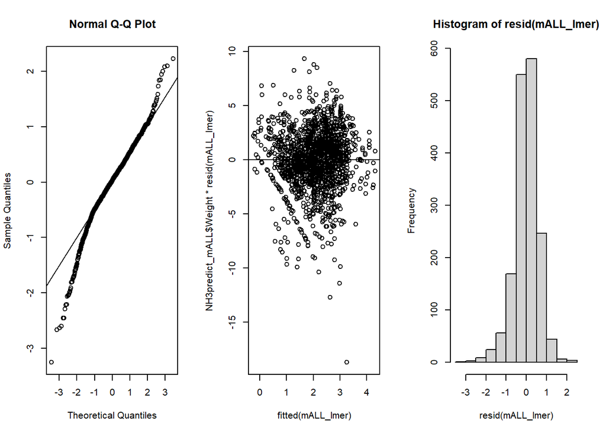

```
## Type III Analysis of Variance Table with Satterthwaite's method
##                    Sum Sq Mean Sq NumDF   DenDF F value    Pr(>F)
## Fertiliser        1131.06  377.02     3 1582.38 212.542 < 2.2e-16 ***
## Application        137.24   45.75     3 1294.10  25.789 3.329e-16 ***
## Method              66.99   11.16     6  253.06   6.294 3.489e-06 ***
## Place               25.82   25.82     1  216.58  14.556 0.0001775 ***
## pH_cat             142.81  142.81     1 1672.31  80.508 < 2.2e-16 ***
## Clay                58.99   58.99     1 1597.16  33.255 9.684e-09 ***
## AirTemperature      67.76   67.76     1 1605.65  38.197 8.091e-10 ***
## Fertiliser:pH_cat   93.76   31.25     3 1635.08  17.619 2.943e-11 ***
## ---
## Signif. codes:  0 '***' 0.001 '**' 0.01 '*' 0.05 '.' 0.1 ' ' 1
```

```
## Linear mixed model fit by REML. t-tests use Satterthwaite's method [
## lmerModLmerTest]
## Formula: sign(NH3loss) * abs(NH3loss)^(1/3) ~ Fertiliser + Application +
##     Method + Place + pH_cat + Fertiliser:pH_cat + Clay + AirTemperature +
##     (1 | Ref)
##    Data: NH3predict_mALL
## Weights: Weight
## Control: lmerControl(optimizer = "bobyqa")
##
## REML criterion at convergence: 3518.8
##
## Scaled residuals:
##     Min      1Q  Median      3Q     Max
## -5.8575 -0.5128  0.0321  0.5937  3.4202
##
## Random effects:
##  Groups   Name        Variance Std.Dev.
##  Ref      (Intercept) 0.3298   0.5742
##  Residual             1.7739   1.3319
## Number of obs: 1693, groups:  Ref, 159
##
## Fixed effects:
##                                     Estimate Std. Error         df t value
## (Intercept)                        2.569e+00  1.364e-01  5.122e+02  18.829
## FertiliserUAN                     -5.100e-01  1.462e-01  1.573e+03  -3.489
## Fertiliserammonium+1              -9.844e-01  9.230e-02  1.672e+03 -10.665
## Fertiliserammonium+2              -1.638e+00  6.193e-02  1.588e+03 -26.453
## ApplicationIncorporated           -7.002e-01  8.338e-02  1.333e+03  -8.397
## ApplicationInjected               -6.509e-01  2.174e-01  1.671e+03  -2.994
## ApplicationLiquid                 -1.588e-01  1.011e-01  1.018e+03  -1.570
## Method15N                         -3.300e-01  3.926e-01  1.640e+03  -0.841
## MethodClosed chamber              -6.881e-01  1.581e-01  3.189e+02  -4.353
## MethodDrager-Tube                 -1.012e+00  2.816e-01  1.407e+02  -3.594
## MethodSemi-open                   -1.352e-01  2.046e-01  1.998e+02  -0.661
## MethodVentilated chambers         -6.239e-01  1.457e-01  5.479e+02  -4.282
## MethodWindtunnel                   3.412e-02  1.804e-01  3.113e+02   0.189
## PlaceLab                           4.635e-01  1.215e-01  2.166e+02   3.815
## pH_catchalky                       1.280e-01  5.062e-02  1.670e+03   2.528
## Clay                              -9.009e-03  1.562e-03  1.597e+03  -5.767
## AirTemperature                     2.085e-02  3.374e-03  1.606e+03   6.180
```

[output cut: 11 more lines]

```
## Method15N                         0.400727
## MethodClosed chamber              1.81e-05 ***
## MethodDrager-Tube                 0.000450 ***
## MethodSemi-open                   0.509645
## MethodVentilated chambers         2.19e-05 ***
## MethodWindtunnel                  0.850121
## PlaceLab                          0.000177 ***
## pH_catchalky                      0.011549 *
## Clay                              9.68e-09 ***
## AirTemperature                    8.09e-10 ***
## FertiliserUAN:pH_catchalky        0.001810 **
## Fertiliserammonium+1:pH_catchalky 3.93e-07 ***
## Fertiliserammonium+2:pH_catchalky 3.06e-08 ***
## ---
## Signif. codes:  0 '***' 0.001 '**' 0.01 '*' 0.05 '.' 0.1 ' ' 1
```

```
##
## Correlation matrix not shown by default, as p = 20 > 12.
## Use print(x, correlation=TRUE)  or
##     vcov(x)        if you need it
```

```
##            R2m       R2c
## [1,] 0.1745003 0.3039022
```

Model A4 explains 30.39 % of the variation in the data (conditional R2), with the fixed effects explaining 17.45 % (marginal R2).

```
##                Factor               Level    Effect        SE         df
## 1          Fertiliser               urea+ 21.451252 0.1230460  1449.5003
## 2          Fertiliser                 UAN 11.674535 0.1868420  3037.2673
## 3          Fertiliser          ammonium+1  5.775757 0.1500045  2508.6930
## 4          Fertiliser          ammonium+2  1.483059 0.1347577  1871.0193
## 5         Application           Broadcast 21.451252 0.1230460  1449.5003
## 6         Application        Incorporated  8.978053 0.1456655  2043.5727
## 7         Application            Injected  9.631270 0.2503621 10665.9046
## 8         Application              Liquid 17.978960 0.1541785  1634.0332
## 9              Method            Micromet 21.451252 0.1230460  1449.5003
## 10             Method                 15N 14.680534 0.3780444 12811.5909
## 11             Method      Closed chamber  9.134939 0.1189399   354.2747
## 12             Method         Drager-Tube  5.514032 0.2587683   167.7743
## 13             Method           Semi-open 18.470144 0.1656652   525.7543
## 14             Method Ventilated chambers 10.002864 0.1112590   542.6524
```

[output cut: 41 more lines]

The same effect sizes (and their 95% confidence interval) are shown below:

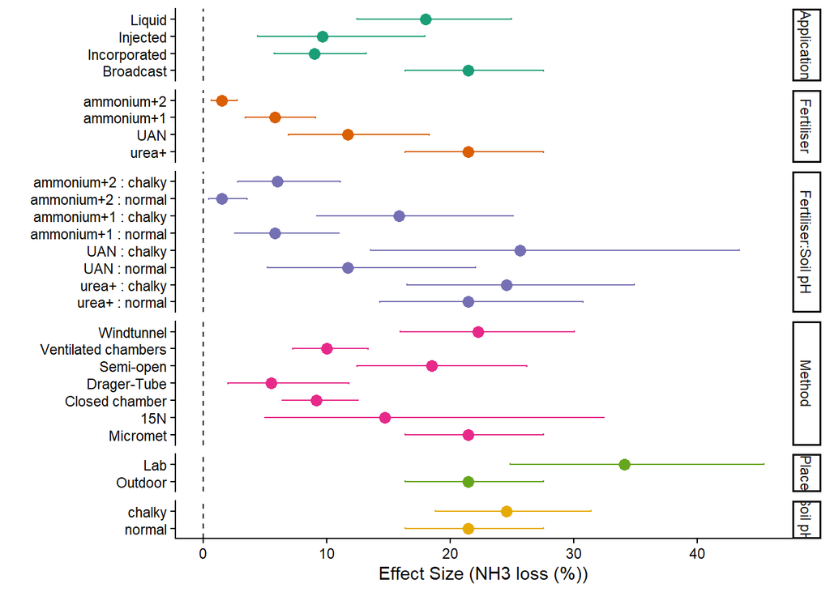

### Model A5

```
## Type III Analysis of Variance Table with Satterthwaite's method
##                          Sum Sq Mean Sq NumDF  DenDF F value    Pr(>F)
## Fertiliser               326.68 108.895     3 900.79 60.2219 < 2.2e-16 ***
## Application               37.09  12.364     3 819.08  6.8375 0.0001491 ***
## Method                    46.95   7.826     6 140.88  4.3278 0.0004871 ***
## pH_cat                    27.62  27.619     1 906.03 15.2740 9.991e-05 ***
## AirTemperature            17.95  17.949     1 796.35  9.9263 0.0016902 **
## Rain.mean                 12.84  12.839     1 876.73  7.1003 0.0078488 **
## Fertiliser:pH_cat         36.45  12.149     3 912.26  6.7188 0.0001740 ***
## AirTemperature:Rain.mean   5.97   5.971     1 873.53  3.3022 0.0695318 .
## ---
## Signif. codes:  0 '***' 0.001 '**' 0.01 '*' 0.05 '.' 0.1 ' ' 1
```

```
## Linear mixed model fit by REML. t-tests use Satterthwaite's method [
## lmerModLmerTest]
## Formula: sign(NH3loss) * abs(NH3loss)^(1/3) ~ Fertiliser + Application +
##     Method + pH_cat + Fertiliser:pH_cat + AirTemperature + Rain.mean +
##     AirTemperature * Rain.mean + (1 | Ref)
##    Data: NH3predict_mALL3
## Weights: Weight
## Control: lmerControl(optimizer = "bobyqa")
##
## REML criterion at convergence: 2048.1
##
## Scaled residuals:
##     Min      1Q  Median      3Q     Max
## -3.8724 -0.4741  0.0298  0.5819  3.1089
##
## Random effects:
##  Groups   Name        Variance Std.Dev.
##  Ref      (Intercept) 0.2782   0.5274
##  Residual             1.8082   1.3447
## Number of obs: 941, groups:  Ref, 102
##
## Fixed effects:
##                                     Estimate Std. Error         df t value
## (Intercept)                         2.253020   0.155029 232.744541  14.533
## FertiliserUAN                      -0.480131   0.182858 909.945088  -2.626
## Fertiliserammonium+1               -0.897562   0.160730 909.200736  -5.584
## Fertiliserammonium+2               -1.474686   0.076229 874.845191 -19.346
## ApplicationIncorporated            -0.444748   0.107107 857.825760  -4.152
## ApplicationInjected                -0.649216   0.330514 879.822528  -1.964
## ApplicationLiquid                  -0.029961   0.147901 757.135123  -0.203
## Method15N                           0.084743   0.402099 825.868298   0.211
## MethodClosed chamber               -0.317523   0.177853 110.114958  -1.785
## MethodDrager-Tube                  -0.636494   0.242090  89.064254  -2.629
## MethodSemi-open                     0.017158   0.201256 126.192733   0.085
## MethodVentilated chambers          -0.615284   0.186377 204.177225  -3.301
## MethodWindtunnel                    0.186894   0.183021 151.158500   1.021
## pH_catchalky                       -0.034563   0.086821 786.141748  -0.398
## AirTemperature                      0.017184   0.005454 796.349304   3.151
## Rain.mean                          -0.097651   0.036647 876.726209  -2.665
## FertiliserUAN:pH_catchalky          0.496603   0.195881 920.384778   2.535
```

[output cut: 11 more lines]

```
## Method15N                         0.833133
## MethodClosed chamber              0.076963 .
## MethodDrager-Tube                 0.010082 *
## MethodSemi-open                   0.932196
## MethodVentilated chambers         0.001136 **
## MethodWindtunnel                  0.308809
## pH_catchalky                      0.690669
## AirTemperature                    0.001690 **
## Rain.mean                         0.007849 **
## FertiliserUAN:pH_catchalky        0.011402 *
## Fertiliserammonium+1:pH_catchalky 0.000494 ***
## Fertiliserammonium+2:pH_catchalky 0.024623 *
## AirTemperature:Rain.mean          0.069532 .
## ---
## Signif. codes:  0 '***' 0.001 '**' 0.01 '*' 0.05 '.' 0.1 ' ' 1
```

```
##
## Correlation matrix not shown by default, as p = 20 > 12.
## Use print(x, correlation=TRUE)  or
##     vcov(x)        if you need it
```

# References

Astivia, Oscar L. Olvera and Zumbo, Bruno D. (2019) “Heteroskedasticity in Multiple Regression Analysis: What it is, How to Detect it and How to Solve it with Applications in R and SPSS,” Practical Assessment, Research, and Evaluation: Vol. 24 , Article 1. DOI: https://doi.org/10.7275/q5xr-fr95

Douglas Bates, Martin Maechler, Ben Bolker, Steve Walker (2015). Fitting Linear Mixed-Effects Models Using lme4. Journal of Statistical Software, 67(1), 1-48. https://doi:10.18637/jss.v067.i01

Nakagawa, S, Schielzeth, H. (2013). A general and simple method for obtaining R^2 from Generalized Linear Mixed-effects Models. Methods in Ecology and Evolution 4: 133-142. https://doi.org/10.1111/j.2041-210x.2012.00261.x